# **AnThroM**

**testing the relation between Theory-of-Mind network activation and dispositional anthropomorphism**  
by *Ruud Hortensius and Michaela Kent (University of Glasgow) - June 2019 - …*

# 1. Details

## 1.1 Data

Data of the Theory-of-Mind functional localiser and Individual Differences in Anthropomorphism Questionnaire are from five different studies.

Dataset_1: Bangor Imaging Unit; EMBOTS; *n*=29 (including 1 pilot scan); full dataset and publication: [Cross…Hortensius (2019) PTRB](https://royalsocietypublishing.org/doi/10.1098/rstb.2018.0034).

Dataset_2: Centre for Cognitive NeuroImaging; SHAREDBOTS; *n*=35 (including 2 pilot scans) publication: Hortensius & Cross, in preparation.

Dataset_3: Centre for Cognitive NeuroImaging; Two studies with the same parameters: *n*=22 (including 2 pilot scans). Social_Gradient_1; *n*=10 (pilot experiment) and BOLDlight; *n*=12.

Dataset_4: Centre for Cognitive NeuroImaging; GAMEBOTS; *n*=22.

Get info for table S1:

```r
library("tidyverse")

#load own data
DF.dataset1 <- read_tsv(file = "/Volumes/Project0255/dataset_1/participants.tsv")
DF.dataset2 <- read_tsv(file = "/Volumes/Project0255/dataset_2/participants.tsv")
DF.dataset3 <- read_tsv(file = "/Volumes/Project0255/dataset_3/participants.tsv")
DF.dataset4 <- read_tsv(file = "/Volumes/Project0255/dataset_4/participants.tsv")

#combine data
bind_rows(DF.dataset1, DF.dataset2, DF.dataset3,  DF.dataset4, .id = "dataset") %>%
  group_by(dataset) %>%
  summarise(mean = mean(age),
            sd = sd(age))
bind_rows(DF.dataset1, DF.dataset2, DF.dataset3,  DF.dataset4, .id = "dataset") %>%
  group_by(dataset, sex) %>%
  tally()
```

## 1.2 Neuroimaging procedure

All participants completed a Theory-of-Mind localiser ([Jacoby et al., 2016](https://www.sciencedirect.com/science/article/pii/S1053811915010472); [Richardson et al. 2018](https://www.nature.com/articles/s41467-018-03399-2)) and an anatomical scan either in the same session or in two seperate sessions. During the localiser participants passively viewed a short 5.6 min animated film ([Partly Cloudy](https://www.pixar.com/partly-cloudy#partly-cloudy-1)). This movie includes scenes depicting pain (e.g. an alligator biting the main character) and events that trigger mentalizing (e.g. the main character revealing its intention). For dataset_3 and dataset_4 a fieldmap was collected as well. At the end of each experiment participants completed the Individual Differences in Anthropomorphism Questionnaire (IDAQ) ([Waytz et al., 2010](https://journals.sagepub.com/doi/full/10.1177/1745691610369336)).

- BOLD:  
  Dataset_1: 3x3x3.5mm voxels, 32 slices, repetition time = 2s, echo time = 30ms  
  Dataset_2: 3mm isotropic, 37 slices, TR = 2s, TE = 30ms  
  Dataset_3: 2mm isotropic, 68 slices, TR = 2s, TE = 26ms  
  Dataset_4: 2.75 x 2.75 x 4mm, 32 slices, TR = 2s, TE = 13 and 31ms
- T1W:  
  Dataset_1: 1mm isotropic resolution, TR = 12ms, TE = 3.47 / 5.15 / 6.83 / 8.52 / 10.20ms (SENSE)  
  Dataset_2 - 4: 1mm isotropic resolution, TR = 2.3s, TE = 29.6ms (ADNI)
- Fieldmaps:  
  Dataset_1: no, so –use-syn-sdc  
  Dataset_2: no, so –use-syn-sdc  
  Dataset_3: yes  
  Dataset_4: yes

## 1.3 To do

- remove Dicoms after BIDS dataset creation
- run formal analyses (Bayesian)

Note: for the code chunk the language is listed, but all except for r-chunks are executed in the terminal

# 2. BIDS dataset

## 2.1 Creating the BIDS dataset

For this you need HeuDiConv [Heuristic DICOM Converter](https://github.com/nipy/heudiconv).  
Based on the tutorial by [Franklin Feingold](http://reproducibility.stanford.edu/bids-tutorial-series-part-2a/).

Dowload the latest version of Heudiconv (we used 0.6.0.dev1):

```bash
docker pull nipy/heudiconv:latest
```

If on the GRID do:

```bash
singularity pull docker://nipy/heudiconv:latest
```

Create the info file (dataset_2 - 4):

```bash
docker run --rm -it -v /Volumes/Project0255/:/base nipy/heudiconv:latest -d /base/dataset_3/sourcedata/sub-{subject}/*.IMA -o /base/dataset_3 -f convertall -s 315 -c none --overwrite
```

For dataset_1 we first need to convert the .dcm from jpeg-2000 lossless to uncompressed dcm (thanks to Michele Svanera for the code):

```
python3 convert_all_compressed_dicom.py
```

Create the info file (dataset_1):

```bash
docker run --rm -it -v /Volumes/Project0255/:/base nipy/heudiconv:latest -d /base/dataset_1/sourcedata/sub-{subject}/ses-{session}/*.dcm -o /base/dataset_1 -f convertall -s 129 -ss 01 -c none --overwrite
```

Get the info file:

```bash
cp /Volumes/Project0255/code/.heudiconv/301/info/dicominfo.tsv /Volumes/Project0255/code
```

## 2.2 Create the heuristic file

Create the following python file and save it in the code folder. There is one functional task (func_movie) and one anatomical (t1w). Dataset_3 and 4 have a field map as well (fmap_phase and fmap_magnitude)

Create a heuristic to automatically convert the files:

```python
import os
def create_key(template, outtype=('nii.gz',), annotation_classes=None):
    if template is None or not template:
        raise ValueError('Template must be a valid format string')
    return template, outtype, annotation_classes
def infotodict(seqinfo):
    """Heuristic evaluator for determining which runs belong where
    allowed template fields - follow python string module:
    item: index within category
    subject: participant id
    seqitem: run number during scanning
    subindex: sub index within group
    session: session id (only for dataset_1)
    """

    t1w1 = create_key('sub-{subject}/{session}/anat/sub-{subject}_{session}_T1w')
    func_movie1 = create_key('sub-{subject}/{session}/func/sub-{subject}_{session}_task-movie_bold')

    t1w = create_key('sub-{subject}/anat/sub-{subject}_T1w')
    func_movie = create_key('sub-{subject}/func/sub-{subject}_task-movie_bold')
    func_movie_echo_1 = create_key('sub-{subject}/func/sub-{subject}_task-movie_echo-1_bold')
    func_movie_echo_2 = create_key('sub-{subject}/func/sub-{subject}_task-movie_echo-2_bold')
    fmap_phase = create_key('sub-{subject}/fmap/sub-{subject}_phasediff')
    fmap_magnitude = create_key('sub-{subject}/fmap/sub-{subject}_magnitude')

    info = {t1w1: [], func_movie1: [], t1w: [], func_movie: [], fmap_phase: [], fmap_magnitude: [],
            func_movie_echo_1: [], func_movie_echo_2: []}

    for idx, s in enumerate(seqinfo):
        if ('T1W_1mm_sag SENSE' in s.protocol_name):
            info[t1w1].append(s.series_id)
        if ('ToM_PartlyCloudy SENSE' in s.protocol_name):
            info[func_movie1].append(s.series_id)
        if ('t1_mpr_ns_sag_iso_ADNI_32ch' in s.protocol_name):
            info[t1w].append(s.series_id)
        if ('t1_mpr_ns_sag_P2_ADNI_32ch' in s.protocol_name):
            info[t1w].append(s.series_id)
        if (s.dim4 == 175) and ('FMRI_MB2_p2_2MMISO_TR2_movie' in s.protocol_name):
            info[func_movie].append(s.series_id)
        if (s.dim4 == 175) and ('FMRI_MB2_movie_p2_2MMISO_TR2' in s.protocol_name):
            info[func_movie].append(s.series_id)
        if (s.dim4 == 170) and ('ep2d_ToM_Loc' in s.protocol_name):
            info[func_movie].append(s.series_id)
        if (s.dim4 == 175) and ('ep2d_ToM_Loc' in s.protocol_name):
            info[func_movie].append(s.series_id)
        if (s.dim4 == 175) and ('ep2d_ToM_Loc_boldTR2' in s.protocol_name):
            info[func_movie].append(s.series_id)
        if (s.TE == 13) and ('BP_ep2d_multiecho_32ch_p3_TOM' in s.protocol_name):
            info[func_movie_echo_1].append(s.series_id)
        if (s.TE == 31.36) and ('BP_ep2d_multiecho_32ch_p3_TOM' in s.protocol_name):
            info[func_movie_echo_2].append(s.series_id)
        if (s.dim3 == 92) and ('gre_field_mapping_AAH' in s.protocol_name):
            info[fmap_magnitude].append(s.series_id)
        if (s.dim3 == 46) and ('gre_field_mapping_AAH' in s.protocol_name):
            info[fmap_phase].append(s.series_id)
        if (s.dim3 == 64) and ('gre_field_mapping_AAH' in s.protocol_name):
            info[fmap_magnitude].append(s.series_id)
        if (s.dim3 == 32) and ('gre_field_mapping_AAH' in s.protocol_name):
            info[fmap_phase].append(s.series_id)
    return info
```

Use the heuristic file to convert the Dicom files to .nii.gz (nifti) and create .json files:

```bash
docker run --rm -it -v /Volumes/Project0255/:/base nipy/heudiconv:latest -d /base/dataset_4/sourcedata/sub-{subject}/*.IMA -o /base/dataset_4 -f /base/code/heuristic_anthrom.py -s 401 -c dcm2niix -b --overwrite
```

```bash
docker run --rm -it -v /Volumes/Project0255/:/base nipy/heudiconv:latest -d /base/dataset_1/sourcedata/sub-{subject}/ses-{session}/*.dcm -o /base/dataset_1 -f /base/code/heuristic_anthrom.py -s 121 -ss 02 -c dcm2niix -b --overwrite
```

On the grid do (Sub-116 was done manually in dcm2niigui):

Type in bash before running

Dataset_1:

```bash
singularity run -B /analyse/Project0255/:/base /analyse/Project0255/my_images/heudiconv_latest.sif -d /base/dataset_1/sourcedata/sub-{subject}/ses-{session}/*.dcm -o /base/dataset_1/ -f /base/code/heuristic_anthrom.py -s 116 -ss 01 -c dcm2niix -b --overwrite
```

Dataset_2 - 4:

```bash
singularity run -B /analyse/Project0255/:/base /analyse/Project0255/my_images/heudiconv_latest.sif -d /base/dataset_2/sourcedata/sub-{subject}/*.IMA -o /base/dataset_2/ -f /base/code/heuristic_anthrom.py -s 201 -c dcm2niix -b --overwrite
```

## 2.3 Anonymize the data

Deface using [Pydeface](https://github.com/poldracklab/pydeface):

```bash
#!/bin/bash

set -e
####For loop that defaces the MRI per subject and replaces the old MRI with the new defaced MRI
rootfolder=/Volumes/Project0255/dataset_4

for subj in 401; do
    echo "Defacing participant $subj"
pydeface ${rootfolder}/sub-${subj}/anat/sub-${subj}_T1w.nii.gz
rm -f ${rootfolder}/sub-${subj}/anat/sub-${subj}_T1w.nii.gz
mv ${rootfolder}/sub-${subj}/anat/sub-${subj}_T1w_defaced.nii.gz ${rootfolder}/sub-${subj}/anat/sub-${subj}_T1w.nii.gz
done
```

For dataset_1: ses-01: 101 102 103 107 112 113 117 118 119 122 123 124 128 ses-02: 104 105 106 108 109 110 111 115 116 120 121 125 126 127

```bash
#!/bin/bash

set -e
rootfolder=/Volumes/Project0255/dataset_1

for subj in 129; do
    echo "Defacing participant $subj"
for session in 01; do
for echo in 1 2 3 4 5; do
pydeface ${rootfolder}/sub-${subj}/ses-${session}/anat/sub-${subj}_ses-${session}_echo-${echo}_T1w.nii.gz
rm -f ${rootfolder}/sub-${subj}/ses-${session}/anat/sub-${subj}_ses-${session}_echo-${echo}_T1w.nii.gz
mv ${rootfolder}/sub-${subj}/ses-${session}/anat/sub-${subj}_ses-${session}_echo-${echo}_T1w_defaced.nii.gz ${rootfolder}/sub-${subj}/ses-${session}/anat/sub-${subj}_ses-${session}_echo-${echo}_T1w.nii.gz
done
done
done
```

## 2.4 Update the .json file for the fmaps for dataset_3 and dataset_4

You need to specify “IntendedFor” field in the _phasediff.json files to point which scans the estimated fieldmap should be applied to.

Run the following script (thanks to Michele Svanera for the code):

```python
python change_json.py
```

## 2.5 Combine the dual-echo runs for dataset_4

For dataset_4 we need to combine the two echo’s (see [NeuroStar](https://neurostars.org/t/fmriprep-does-not-combine-multi-echo-timeseries/3398/2) for more info. We created a dual_sum volume by adding the two images together (see [Halai et al. 2014](https://onlinelibrary.wiley.com/doi/full/10.1002/hbm.22463).

Run the following script (thanks to Tyler Morgan for the code):

```python
python sum_echo.py
```

## 2.6 Theory-of-Mind event protocols

Create tsv file for functional localiser. Event coding (in s; 10s of fixation before movie starts; accounting for hemodynamic lag) is based on Richardson et al. 2018 - reverse correlation analyses.

Note: For sub-322 the trigger was at the start of the movie (thus create a different tsv, with event - 10s). Check the triggers for dataset_1.

```r
PartlyCloudy <- data.frame(onset = c(86, 98, 120, 176, 238, 252, 300, 70, 92, 106, 136, 194, 210, 228, 262, 312), #create the events (same for every sub)
                           duration = c(4, 6, 4, 16, 6, 8, 6, 4, 2, 4, 10, 4, 12, 6, 6, 4),
                           trial_type = c(rep("mental",7), rep("pain",9)))

#dataset_1
for (sub in 102:129){ #note: localisers for sub-101 are in ses-02
  filename = paste("/Volumes/Project0255/dataset_1/sub-", sub, "/ses-01/func/sub-", sub, "_ses-01_task-movie_events.tsv", sep ="")
write.table(PartlyCloudy, file = filename, sep="\t", row.names = FALSE, quote = FALSE)
}
#dataset_2
for (sub in 201:235){
  filename = paste("/Volumes/Project0255/dataset_2/sub-", sub, "/func/sub-", sub, "_task-movie_events.tsv", sep ="")
write.table(PartlyCloudy, file = filename, sep="\t", row.names = FALSE, quote = FALSE)
}
#dataset_3
for (sub in 301:322){ #note: localisers for sub-322 should have t-10 (no trigger) <-manually correct this
  filename = paste("/Volumes/Project0255/dataset_3/sub-", sub, "/func/sub-", sub, "_task-movie_events.tsv", sep ="")
write.table(PartlyCloudy, file = filename, sep="\t", row.names = FALSE, quote = FALSE)
}
#dataset_4
for (sub in 401:422){
  filename = paste("/Volumes/Project0255/dataset_4/sub-", sub, "/func/sub-", sub, "_task-movie_events.tsv", sep ="")
write.table(PartlyCloudy, file = filename, sep="\t", row.names = FALSE, quote = FALSE)
}
```

## 2.6 BIDS validation

Use the BIDS-Validator to check if the dataset is BIDS compliant:

```bash
docker run -ti --rm -v /Volumes/Project0255/dataset_4:/data:ro bids/validator /data
```

# 3. Preprocessing

## 3.1 Run MRQIC

MRIQC is a docker tool to do quality control of the data. More info [here](https://poldracklab.github.io/mriqc/).

MRIQC 0.14.2 was used:

```bash
docker run -it --rm -v /Volumes/Project0255/dataset_1/:/data:ro -v /Volumes/Project0255/dataset_1/derivatives/mriqc:/out poldracklab/mriqc:0.14.2 /data /out participant --participant-label 101 -m T1w bold --ica --fft-spikes-detector
```

On the grid do (cd in /analyse folder):

```bash
singularity run --cleanenv /analyse/Project0255/my_images/mriqc-0.14.2.simg /analyse/Project0255/dataset_1 /analyse/Project0255/dataset_1/derivatives/mriqc participant --participant-label 123 -m T1w bold --ica --fft-spikes-detector -w /analyse/Project0255/work
```

Run it seperately for the datasets. Change participant to group to create the group reports:

```bash
docker run -it --rm -v /Volumes/Project0255/dataset_4/:/data:ro -v /Volumes/Project0255/dataset_4/derivatives/mriqc:/out poldracklab/mriqc:0.14.2 /data /out group
```

## 3.2 Compare MRIQC

Plot the output. This is based on [MRIQCeption](https://github.com/elizabethbeard/mriqception). The MRIQCeption Visualization by Catherine Walsh was adapted. Adjust the filter if you want to look at different measures.

Adjust this to your liking (e.g. bold: fd_mean, fd_perc, dvars_std, dvars_vstd, gcor, tsnr, t1w: cjv, cnr, snr, efc, inu, wm2max, fwhm) and modality (bold or t1w):

```r
QCmeasure <- "fd_mean"
modality <- "bold"
```

Run the following code. Change the script below to load the group results for the different datasets:

```r
#libraries
library("tidyverse")
source("/Volumes/Project0255/code/R_rainclouds.R")

#load own data
DF.dataset1  <- read_tsv(file = paste("/Volumes/Project0255/dataset_1/derivatives/mriqc/group_", modality, ".tsv", sep ="")) %>%
  gather("measure", "value", 2:46) %>%
  select("bids_name","measure", "value")

DF.dataset2 <- read_tsv(file = paste("/Volumes/Project0255/dataset_2/derivatives/mriqc/group_", modality, ".tsv", sep ="")) %>%
  gather("measure", "value", 2:46) %>%
  select("bids_name","measure", "value")

DF.dataset3 <- read_tsv(file = paste("/Volumes/Project0255/dataset_3/derivatives/mriqc/group_", modality, ".tsv", sep ="")) %>%
  gather("measure", "value", 2:46) %>%
  select("bids_name","measure", "value")

DF.dataset4 <- read_tsv(file = paste("/Volumes/Project0255/dataset_4/derivatives/mriqc/group_", modality, ".tsv", sep ="")) %>%
  gather("measure", "value", 2:46) %>%
  select("bids_name","measure", "value")

#select the most relevant measures
#selectionMeasure <- c("snr", "tsnr", "efc", "fber", "gsr_x", "gsr_y", "dvars_nstd", "dvars_std", "dvars_vstd", "gcor", "fd_mean", "fd_number", "fd_percentage", "spikes", "aor", "aqi")

#combine data
DF.full <- bind_rows(DF.dataset1, DF.dataset2, DF.dataset3,  DF.dataset4, .id = "dataset") %>%
  group_by(dataset) %>%
  filter(measure == QCmeasure) #%in% c(selectionMeasure))

#create raincloud plot (check out the [github](https://github.com/RainCloudPlots/) or [preprint](https://wellcomeopenresearch.org/articles/4-63/v1)
p <- ggplot(DF.full,aes(x=dataset,y=value,fill=dataset))+
  geom_flat_violin(position=position_nudge(x = .2, y = 0),adjust =2, trim = FALSE, alpha = .5, colour = NA)+
  geom_point(aes(colour = dataset), position=position_jitter(width = .05), size = .5, shape = 20)+
  geom_boxplot(aes(x=dataset,y=value),position=position_nudge(x = .1, y = 0),outlier.shape = NA, alpha = .5, width = .1, colour = "black")+
  #facet_wrap(. ~ dataset) +
  theme_classic() + ylab(QCmeasure) + scale_fill_brewer(palette = "Reds") +
  scale_colour_brewer(palette = "Reds") + ggtitle(paste("Comparison of", modality, "QC measure", QCmeasure, "between datasets")) +
  facet_wrap(~measure)
p
```

## 3.3 fMRIprep

fMRIprep is a docker tool for preprocessing of the fMRI data. More info [here](https://fmriprep.readthedocs.io/en/stable/#)

fMRIprep version 1.5.2 was used on a local iMac.

If you run into memory problems you can use –skip_bids_validation; skipped the –write-graph flag to save space, and –use-syn-sdc only for dataset_1 and datatset_2.

If run on the GRID, cd into the analyse folder and run:

```bash
singularity run --cleanenv /analyse/Project0255/my_images/fmriprep-1.5.2.simg /analyse/Project0255/dataset_1/ /analyse/Project0255/dataset_1/derivatives participant --participant-label sub-129 --fs-license-file /analyse/Project0255/my_images/license.txt --skip_bids_validation --use-syn-sd --fs-no-reconall -w /analyse/Project0255/work/compute00
```

Resize functional files for two participants (sub-117 and sub-125) from dataset_1 (sub-{sub}_ses-01_task-movie_space-MNI152NLin2009cAsym_desc-preproc_bold.nii) to allow for group comparison (run this in MATLAB):

```
voxsiz = [3 3 3.5]; % new voxel size {mm}
V = spm_select([1 Inf],'image');
V = spm_vol(V);
for i=1:numel(V)
   bb        = spm_get_bbox(V(i));
   VV(1:2)   = V(i);
   VV(1).mat = spm_matrix([bb(1,:) 0 0 0 voxsiz])*spm_matrix([-1 -1 -1]);
   VV(1).dim = ceil(VV(1).mat \ [bb(2,:) 1]' - 0.1)';
   VV(1).dim = VV(1).dim(1:3);
   spm_reslice(VV,struct('mean',false,'which',1,'interp',0)); % 1 for linear
end
```

# 4. Analyses

## 4.1 Example script for first-level analysis

Example MATLAB script (dataset 3):

```
%========================================================================
%     SPM first-level analysis for fmriprep data in BIDS format
%========================================================================
%     This script is written by Ruud Hortensius and Michaela Kent
%     (University of Glasgow). Based upon a script written by
%     Shengdong Chen (ACRLAB) and Stephan Heunis (TU Eindhoven).
%
%     Added: loop for runs
%     Parameters as specified by Saxelab: https://saxelab.mit.edu/theory-mind-and-pain-matrix-localizer-movie-viewing-experiment
%
%     Last updated: January 2020
%========================================================================

clear all

%% Inputdirs
BIDS = spm_BIDS('/Volumes/Project0255/dataset_3/'); % Parse BIDS directory (easier to query info from dataset)
BIDSpreproc=fullfile(BIDS.dir,'derivatives/fmriprep'); % get the preprocessed directory

%sublist = spm_BIDS(BIDS,'subjects') %number of subjects
sublist = transpose(BIDS.participants.participant_id) %get subject list including the 'sub'
subex = []
sublist(subex) = []; %update the subjects

taskid='movie'; %specify the task to be analysed

numScans=175;  %The number of volumes per run <---

TR = 2;     % Repetition time, in seconds <---
unit='secs'; % onset times in secs (seconds) or scans (TRs)

%% Outputdirs
outputdir=fullfile(BIDS.dir,'derivatives/bids_spm/first_level');  % root outputdir for sublist
spm_mkdir(outputdir,char(sublist), char(taskid)); % create output directory

%% Loop for sublist
spm('Defaults','fMRI'); %Initialise SPM fmri
spm_jobman('initcfg');  %Initialise SPM batch mode

for i=1:length(sublist)
```

[output cut: 74 more lines]

```
    matlabbatch{2}.spm.stats.fmri_est.method.Classical = 1;

    %% Contrasts
    matlabbatch{3}.spm.stats.con.spmmat = {[subdir filesep 'SPM.mat']};
    % Set contrasts of interest.
    matlabbatch{3}.spm.stats.con.consess{1}.tcon.name = 'mental_pain';
    matlabbatch{3}.spm.stats.con.consess{1}.tcon.convec = [1 -1 0 0 0 0 0 0 0 0 0 0 0 0 0];
    matlabbatch{3}.spm.stats.con.consess{2}.tcon.name = 'pain_mental';
    matlabbatch{3}.spm.stats.con.consess{2}.tcon.convec = [-1 1 0 0 0 0 0 0 0 0 0 0 0 0 0];
    matlabbatch{3}.spm.stats.con.delete = 0;

    %% Run matlabbatch jobs
    spm_jobman('run',matlabbatch);

end
```

## 4.2 First-level analysis

Run the followin commands in the terminal.

Dataset_1:

```bash
cd "/Volumes/Project0255/code/"
matlab -batch "BIDS_SPM_firstlevel_tom_dataset1"
matlab -batch "BIDS_SPM_firstlevel_tom_dataset1_ppn101"
matlab -batch "BIDS_SPM_firstlevel_tom_dataset1_ppn114"
```

Dataset_2:

```bash
cd "/Volumes/Project0255/code/"
matlab -batch "BIDS_SPM_firstlevel_tom_dataset2_ppn201_202"
```

Dataset_3:

```bash
cd "/Volumes/Project0255/code/"
matlab -batch "BIDS_SPM_firstlevel_tom_dataset3"
```

Dataset_4:

```bash
cd "/Volumes/Project0255/code/"
matlab -batch "BIDS_SPM_firstlevel_tom_dataset4"
```

## 4.3 Create group mask

Create a group average for the GM_probseg.nii for each dataset in Matlab (change the code per dataset; run this in MATLAB):

```
clear all

spm('Defaults','fMRI');
spm_jobman('initcfg');

BIDS = spm_BIDS('/Volumes/Project0255/dataset_3'); %change this
BIDSfirst=fullfile(BIDS.dir,'derivatives/fmriprep');

sublist = transpose(BIDS.participants.participant_id)
subex = [] %subjects that don't have an anatomical (14 dataset_1)
sublist(subex) = [];

for i=1:length(sublist)
    subdir=fullfile(BIDSfirst,sublist{i}, 'anat')
    matlabbatch{1}.spm.util.imcalc.input{i,1} = [subdir, filesep, sublist{i}, '_space-MNI152NLin2009cAsym_label-GM_probseg.nii,1']
end
matlabbatch{1}.spm.util.imcalc.output = 'dataset3_averageGM';
matlabbatch{1}.spm.util.imcalc.outdir = {'/Volumes/Project0255/dataset_3/derivatives/fmriprep'}; %change this
matlabbatch{1}.spm.util.imcalc.expression = 'mean(X)';
matlabbatch{1}.spm.util.imcalc.var = struct('name', {}, 'value', {});
matlabbatch{1}.spm.util.imcalc.options.dmtx = 1;
matlabbatch{1}.spm.util.imcalc.options.mask = 0;
matlabbatch{1}.spm.util.imcalc.options.interp = 1;
matlabbatch{1}.spm.util.imcalc.options.dtype = 4;

spm_jobman('run',matlabbatch);
```

## 4.4 Example script for second-level whole-brain analysis

Example MATLAB script (dataset 3):

```
%========================================================================
%     SPM second-level analysis for fmriprep data in BIDS format
%========================================================================
%     This script is written by Ruud Hortensius and Michaela Kent
%     (University of Glasgow)
%
%     Last updated: January 2020
%========================================================================


clear all

%% Inputdirs
BIDS = spm_BIDS('/Volumes/Project0255/dataset_3'); % Parse BIDS directory (easier to query info from dataset)
BIDSfirst=fullfile(BIDS.dir,'derivatives/bids_spm/first_level'); % get the first-level directory

sublist = transpose(BIDS.participants.participant_id) %get subject list including the 'sub'
subex = [] %subjects that don't have a second-session
sublist(subex) = []; %update the subjects

%nsession = spm_BIDS(BIDS,'sessions') %how many sessions? careful, sometimes collapsing across sessions not wanted
%sessionid = 'ses-01' %get session id

taskid='movieHC'; %specify the task to be analysed

contrast='con_0001'; %specify the contrast to be analysed
contrast_name='mental_hc'; %specify the name of the contrast

smoothing = 1; %soomthing of first-level contrasts (1=yes, 0=no)
s_kernel = [5 5 5]

%% Outputdirs
outputdir=fullfile(BIDS.dir,'derivatives/bids_spm/second_level', char(contrast_name));  % root outputdir for sublist
spm_mkdir(outputdir); % create output directory

spm('Defaults','fMRI'); %Initialise SPM fmri
spm_jobman('initcfg');  %Initialise SPM batch mode


%% Smoothing of first-level contrasts
```

[output cut: 53 more lines]

```
matlabbatch{4}.spm.stats.results.conspec.contrasts = 1;
matlabbatch{4}.spm.stats.results.conspec.threshdesc = 'none';
matlabbatch{4}.spm.stats.results.conspec.thresh = 0.001;
matlabbatch{4}.spm.stats.results.conspec.extent = 5;
matlabbatch{4}.spm.stats.results.conspec.conjunction = 1;
matlabbatch{4}.spm.stats.results.conspec.mask.image.name = {'/Volumes/Project0255/dataset_3/derivatives/fmriprep/dataset3_averageGM.nii,1'};
matlabbatch{4}.spm.stats.results.conspec.mask.image.mtype = 0;
matlabbatch{4}.spm.stats.results.units = 1;
matlabbatch{4}.spm.stats.results.export{1}.pdf = true;
matlabbatch{4}.spm.stats.results.export{2}.jpg = true;
matlabbatch{4}.spm.stats.results.export{3}.csv = true;
matlabbatch{4}.spm.stats.results.export{4}.tspm.basename = contrast_name;

%% Run matlabbatch jobs
spm_jobman('run',matlabbatch);
```

## 4.5 Second-level whole-brain analysis

Run it seperately for the datasets:

```bash
cd "/Volumes/Project0255/code/"
matlab -batch "BIDS_SPM_secondlevel_tom_dataset1"
matlab -batch "BIDS_SPM_secondlevel_tom_dataset2"
matlab -batch "BIDS_SPM_secondlevel_tom_dataset3"
matlab -batch "BIDS_SPM_secondlevel_tom_dataset4"
```

## 4.6 ToM fROI analysis

Run the following (ROI_extract.m) script in matlab (change the code per dataset and roi and contrast - run this in MATLAB):

```
%========================================================================
%     fROI analysis for fmriprep data in BIDS format
%========================================================================
%     This script is written by  Michaela Kent and Ruud Hortensius
%     (University of Glasgow)
%
%     Last updated: January 2020
%========================================================================
clear all
%add marsbar to path
marsbar('on')

%% Inputdirs
BIDS = spm_BIDS('/Volumes/Project0255/dataset_4'); % parse BIDS directory (easier to query info from dataset)
BIDSsecond=fullfile(BIDS.dir,'derivatives/bids_spm/second_level'); % get the second-level directory

contrastid = 'mental' %can be either mental (vs. pain) or pain (vs. mental)
networkid = 'tom' %can be either tom (theory-of-mind) or pain (pain matrix)

%% Outputdirs
outputdir=fullfile(BIDS.dir,'derivatives/roi', networkid);  % root outputdir for sublist
spm_mkdir(outputdir); % create output directory

%% Load design matrix
spm_name = spm_load(fullfile(BIDSsecond, filesep, contrastid , 'SPM.mat'))
D  = mardo(spm_name);


%% Load rois
parcels = dir(fullfile(BIDS.dir,'derivatives/parcels/', networkid))
parcels = struct2cell(parcels(arrayfun(@(x) ~strcmp(x.name(1),'.'),parcels)))
parcels(2:6,:) = []

for i=1:length(parcels)
    roi = fullfile(BIDS.dir,'derivatives/parcels/',  networkid, parcels{i})
    R  = maroi(roi);
    % Fetch data into marsbar data object
    mY  = get_marsy(R, D, 'mean');
    roi_data = summary_data(mY); % get summary time course(s)
    roi_name = [outputdir,filesep,parcels{i},'.tsv'];
    dlmwrite(roi_name,roi_data);
end
```

## 4.7 Custom steps

Add sub-201 and sub-202 to get the fROI data (different parameters, not included in the whole-brain analysis):

```bash
cd "/Volumes/Project0255/code/"
matlab -batch "BIDS_SPM_secondlevel_tom_dataset2_201_202"
matlab -batch "ROI_extract_201_202"
```

# 5. IDAQ

## 5.1 Calculation of individual scores:

Dataset 2: sub-206-212, 219, 221-22, 224-25, 228, 231, 233-34 completed a version with the scale ranging from 1-10 instead of 0-10. Analyses should be run with and without these participants:

```r
sub_ex = c(206:212, 219, 221:222, 224:225, 228, 231, 233:234)
```

Get the IDAQ data for all the participants:

```r
library(tidyverse)
#load data (/Volumes/Project0255/dataset_1/sourcedata/)
DF.d1  <- read_csv(file = paste("IDAQ_dataset1.csv", sep ="")) %>%
  gather("sub", "value", 4:32)
DF.d2  <- read_csv(file = paste("IDAQ_dataset2.csv", sep ="")) %>%
  gather("sub", "value", 4:38)
DF.d3  <- read_csv(file = paste("IDAQ_dataset3.csv", sep ="")) %>%
  gather("sub", "value", 4:25)
DF.d4  <- read_csv(file = paste("IDAQ_dataset4.csv", sep ="")) %>%
  gather("sub", "value", 4:25)
DF.idaq <- bind_rows(DF.d1, DF.d2, DF.d3, DF.d4, .id = "dataset") %>%
  mutate(sub=gsub('sub-','',sub))%>%
  transform(sub=as.integer(sub)) %>%
  mutate(scale = as.factor(ifelse(scale == "IDAQ-NA", "IDAQNA", "IDAQ")))
rm(DF.d1, DF.d2, DF.d3, DF.d4)
```

## 5.2 Reliability of IDAQ

Check the reliability of the IDAQ scale:

```r
library("psych")
DF.idaq %>%
  filter(scale == "IDAQ") %>%
  #filter(!sub %in% sub_ex) %>%
  select(-scale, -subscale)  %>%
  spread(itemnr, value) %>%
  select(-sub, -dataset) %>%
  alpha(na.rm = TRUE)
```

```
Reliability analysis
Call: alpha(x = ., na.rm = TRUE)
```

|  | raw_alpha | std.alpha | G6(smc) | average_r | S/N | ase | mean | sd | median_r |
| --- | --- | --- | --- | --- | --- | --- | --- | --- | --- |
|  | 0.8018188 | 0.8059196 | 0.869336 | 0.2168126 | 4.152503 | 0.0279359 | 3.37716 | 1.220938 | 0.2225996 |

```
 lower alpha upper     95% confidence boundaries
0.75 0.8 0.86

 Reliability if an item is dropped:
```

|  | raw_alpha | std.alpha | G6(smc) | average_r | S/N | alpha se | var.r | med.r |
| --- | --- | --- | --- | --- | --- | --- | --- | --- |
| 3 | 0.8008165 | 0.8005013 | 0.8659411 | 0.2227647 | 4.012563 | 0.02792102 | 0.03623875 | 0.2220538 |
| 4 | 0.7966431 | 0.8014683 | 0.8626917 | 0.2238168 | 4.036979 | 0.02866179 | 0.03486754 | 0.2349564 |
| 7 | 0.7903914 | 0.7935482 | 0.8610129 | 0.2154114 | 3.843746 | 0.02955790 | 0.03784650 | 0.2220538 |
| 9 | 0.8007014 | 0.8056312 | 0.8680556 | 0.2284316 | 4.144859 | 0.02823977 | 0.03536785 | 0.2313872 |
| 11 | 0.7891601 | 0.7916458 | 0.8540051 | 0.2134619 | 3.799519 | 0.02963468 | 0.03700100 | 0.2220538 |
| 12 | 0.7933584 | 0.7986124 | 0.8618125 | 0.2207308 | 3.965550 | 0.02917592 | 0.03527852 | 0.2349564 |
| 13 | 0.7950629 | 0.7960448 | 0.8576560 | 0.2180098 | 3.903039 | 0.02905811 | 0.03585534 | 0.2225996 |
| 14 | 0.7890742 | 0.7922248 | 0.8585794 | 0.2140525 | 3.812894 | 0.02980103 | 0.03796862 | 0.2313872 |
| 17 | 0.7979578 | 0.8017226 | 0.8621148 | 0.2240947 | 4.043440 | 0.02847331 | 0.03352406 | 0.2220538 |
| 20 | 0.7900845 | 0.7976290 | 0.8535666 | 0.2196827 | 3.941420 | 0.02967244 | 0.03101681 | 0.2313872 |

[output cut: 5 more lines]

```
 Item statistics
```

|  | n | raw.r | std.r | r.cor | r.drop | mean | sd |
| --- | --- | --- | --- | --- | --- | --- | --- |
| 3 | 108 | 0.4502850 | 0.4490575 | 0.3852785 | 0.3096151 | 2.9814815 | 2.932198 |
| 4 | 108 | 0.4761460 | 0.4367515 | 0.3888935 | 0.3444865 | 5.8518519 | 2.730290 |
| 7 | 108 | 0.5081932 | 0.5350649 | 0.4862201 | 0.4153881 | 1.2222222 | 2.150129 |
| 9 | 108 | 0.3373812 | 0.3827749 | 0.3137074 | 0.2470516 | 0.8611111 | 1.831492 |
| 11 | 106 | 0.5306940 | 0.5578673 | 0.5281543 | 0.4301568 | 2.2735849 | 2.299205 |
| 12 | 108 | 0.4990623 | 0.4728472 | 0.4267299 | 0.3830816 | 6.0185185 | 2.730860 |
| 13 | 108 | 0.4564611 | 0.5046724 | 0.4672320 | 0.3806849 | 0.6481481 | 1.313587 |
| 14 | 107 | 0.5323490 | 0.5509594 | 0.5095279 | 0.4302201 | 1.7850467 | 2.414688 |
| 17 | 108 | 0.3952449 | 0.4335005 | 0.3868829 | 0.2980930 | 1.9907407 | 1.978838 |
| 20 | 108 | 0.5111925 | 0.4851053 | 0.4698563 | 0.4256332 | 7.7407407 | 1.982967 |

[output cut: 5 more lines]

## 5.3 Reliability of IDAQ-NA

Check the reliability of the IDAQ-NA scale:

```r
DF.idaq %>%
  filter(scale == "IDAQNA") %>%
  filter(!sub %in%  sub_ex) %>%
  select(-scale, -subscale)  %>%
  spread(itemnr, value) %>%
  select(-sub, -dataset) %>%
  alpha(na.rm = TRUE)
```

```
Reliability analysis
Call: alpha(x = ., na.rm = TRUE)
```

|  | raw_alpha | std.alpha | G6(smc) | average_r | S/N | ase | mean | sd | median_r |
| --- | --- | --- | --- | --- | --- | --- | --- | --- | --- |
|  | 0.6179246 | 0.619652 | 0.690329 | 0.09797069 | 1.629171 | 0.05721889 | 6.070393 | 0.961106 | 0.08204914 |

```
 lower alpha upper     95% confidence boundaries
0.51 0.62 0.73

 Reliability if an item is dropped:
```

|  | raw_alpha | std.alpha | G6(smc) | average_r | S/N | alpha se | var.r | med.r |
| --- | --- | --- | --- | --- | --- | --- | --- | --- |
| 1 | 0.5855953 | 0.5927513 | 0.6639523 | 0.09417370 | 1.455502 | 0.06231816 | 0.01881155 | 0.08172151 |
| 2 | 0.6220373 | 0.6246172 | 0.6892141 | 0.10622785 | 1.663948 | 0.05665858 | 0.01950141 | 0.10150943 |
| 5 | 0.5718907 | 0.5775043 | 0.6499557 | 0.08895022 | 1.366888 | 0.06452429 | 0.01771773 | 0.07991834 |
| 6 | 0.5990441 | 0.5990722 | 0.6709461 | 0.09643693 | 1.494215 | 0.06020368 | 0.01913626 | 0.08172151 |
| 8 | 0.6255201 | 0.6336783 | 0.7008033 | 0.10997192 | 1.729841 | 0.05652865 | 0.01920894 | 0.10477950 |
| 10 | 0.5837371 | 0.5869012 | 0.6513557 | 0.09213110 | 1.420729 | 0.06233876 | 0.01759770 | 0.07991834 |
| 15 | 0.6408126 | 0.6332907 | 0.6976998 | 0.10980866 | 1.726956 | 0.05351211 | 0.01869036 | 0.10477950 |
| 16 | 0.5722525 | 0.5690226 | 0.6488569 | 0.08618019 | 1.320307 | 0.06421475 | 0.01853958 | 0.07641402 |
| 18 | 0.5765022 | 0.5800579 | 0.6567170 | 0.08980271 | 1.381281 | 0.06391357 | 0.01913387 | 0.07802135 |
| 19 | 0.6034060 | 0.6010430 | 0.6718934 | 0.09715488 | 1.506536 | 0.05946425 | 0.01976668 | 0.07991834 |

[output cut: 5 more lines]

```
 Item statistics
```

|  | n | raw.r | std.r | r.cor | r.drop | mean | sd |
| --- | --- | --- | --- | --- | --- | --- | --- |
| 1 | 92 | 0.5022522 | 0.4555571 | 0.40006169 | 0.32647903 | 4.641304 | 2.948576 |
| 2 | 92 | 0.2637715 | 0.2716440 | 0.16012053 | 0.10722933 | 6.782609 | 2.329109 |
| 5 | 92 | 0.5520837 | 0.5352530 | 0.51186770 | 0.42055457 | 5.336957 | 2.410039 |
| 6 | 92 | 0.3902430 | 0.4210264 | 0.35055985 | 0.26989040 | 7.793478 | 1.890044 |
| 8 | 92 | 0.2033986 | 0.2145198 | 0.07486183 | 0.06349463 | 4.467391 | 2.024309 |
| 10 | 92 | 0.5001412 | 0.4867215 | 0.46382656 | 0.33997926 | 3.967391 | 2.703076 |
| 15 | 92 | 0.2649712 | 0.2170107 | 0.08842175 | 0.05441752 | 2.173913 | 3.097708 |
| 16 | 92 | 0.5630785 | 0.5775159 | 0.55118538 | 0.44379287 | 8.250000 | 2.136162 |
| 18 | 92 | 0.5462211 | 0.5222463 | 0.47744834 | 0.36711227 | 5.934783 | 3.130159 |
| 19 | 92 | 0.3513635 | 0.4100725 | 0.33488823 | 0.24402100 | 8.163043 | 1.659320 |

[output cut: 5 more lines]

## 5.4 Differences between datasets

Test if there are differences in IDAQ and IDAQ-NA scores between datasets.

Before fitting any model we establish which link function we need to use. This code is taken from [Kevin Stadler’s github](https://kevinstadler.github.io/blog/bayesian-ordinal-regression-with-random-effects-using-brms/). In short, it uses the ordinal package to (quickly) find the link function that fits the data:

```r
library(ordinal)
cumulativemodelfit <- function(formula, data, links=c("logit", "probit", "cloglog", "cauchit"),
    thresholds=c("flexible", "equidistant"), verbose=TRUE) {
  names(links) <- links
  names(thresholds) <- thresholds
  llks <- outer(links, thresholds,
    Vectorize(function(link, threshold)
      # catch error for responses with 2 levels
      tryCatch(ordinal::clm(formula, data=data, link=link, threshold=threshold)$logLik,
        error = function(e) NA)))
  print(llks)
  if (verbose) {
    bestfit <- which.max(llks)
    cat("\nThe best link function is ", links[bestfit %% length(links)], " with a ",
    thresholds[1 + bestfit %/% length(thresholds)], " threshold (logLik ", llks[bestfit],
    ")\n", sep="")
  }
  invisible(llks)
}
```

For the anthropomorphism subscale first:

```r
DF.test = DF.idaq %>%
  filter(scale == "IDAQ") %>%
  mutate_all(as.factor) %>%
  mutate(value = factor(value, levels=c(0:10), ordered=TRUE)) #add contrast coding?
```

Get the link function:

```r
cumulativemodelfit(value ~ 1, data=DF.test)
```

```
         flexible equidistant
logit   -3559.563   -3638.793
probit  -3559.563   -3629.921
cloglog -3559.563   -3663.966
cauchit -3559.563   -3629.921

The best link function is logit with a flexible threshold (logLik -3559.563)
```

1. First cumulative ordinal model with dataset as fixed factor:

```r
library(brms)
options(mc.cores = parallel::detectCores()) #run once (run on multiple cores)
ord.1 <- brm(
  value ~ 1 + dataset,
  data  = DF.test,
  family  = cumulative("logit"),
  file = 'ord.1~simple.RDS'
)
```

Get summary and marginal effects:

```r
summary(ord.1) #prob = .99  for 99 credible intervals
conditional_effects(ord.1, "dataset", categorical = TRUE)
plot(ord.1)
```

2. Second cumulative ordinal model with dataset as fixed factor and random intercepts for participant and itemnr:

```r
ord.2 <- brm(
  value ~ 1 + dataset +
    (1|sub) + (1|itemnr),
  data  = DF.test,
  family  = cumulative("logit"),
  file = 'ord.2~random.RDS'
)
```

Get summary and marginal effects:

```r
summary(ord.2) #prob = .99  for 99 credible intervals
conditional_effects(ord.2, "dataset", categorical = TRUE)
```

3. Category-specific model:

```r
ord.3 <- brm(
  value ~ 1 + cs(dataset) +
    (cs(1)|sub) + (cs(1)|itemnr),
  data  = DF.test,
  family = acat("logit"),
  file = 'ord.3~category.RDS'
)
```

Get summary and marginal effects:

```r
summary(ord.3) #prob = .99  for 99 credible intervals
conditional_effects(ord.3, "dataset", categorical = TRUE)
```

4. Adjecent-category model without category-specific effects (to check if differences between model 2 and 3 are not due to different classes of ordinal models):

```r
ord.4 <- brm(
  value ~ 1 + dataset +
    (1|sub) + (1|itemnr),
  data  = DF.test,
  family = acat("logit"),
  file = 'ord.4~category2.RDS'
)
```

Get summary and marginal effects: #should add 1|itemnr and 1|sub

```r
summary(ord.4) #prob = .99  for 99 credible intervals
conditional_effects(ord.4, "dataset", categorical = TRUE)
```

5. Unequal variances model:

```r
ord.5 <- brm(
  formula = bf(value ~ 1 + dataset) +
    lf(disc ~ 0 + dataset, cmc = FALSE),
  data = DF.test,
  family  = cumulative("logit"),
  file = 'ord.5~control.RDS'
)
```

Get summary and marginal effects:

```r
summary(ord.5) #prob = .99  for 99 credible intervals
conditional_effects(ord.5, "dataset", categorical = TRUE)
```

6. Model comparison:

```r
modelC1 <- LOO(ord.1, ord.2, ord.3, ord.4, ord.5)
save(modelC1, file="modelC1.RData")
load('modelC1.RData')
modelC1
```

7. Rerun winning model excluding the participants that completed the incorrect IDAQ version:

```r
DF.test = DF.test %>%
  filter(!sub %in% sub_ex)

cumulativemodelfit(value ~ 1, data=DF.test)
```

8. Model 2 while excluding these participants:

```r
ord.2E <- brm(
  value ~ 1 + dataset +
    (1|sub) + (1|itemnr),
  data  = DF.test,
  family = cumulative(link = "probit", threshold="equidistant"),
  file = 'ord.2E~random.RDS'
)
```

Get summary and marginal effects:

```r
summary(ord.2E) #prob = .99  for 99 credible intervals
conditional_effects(ord.2E, "dataset", categorical = TRUE)
```

## 5.5 IDAQ per subject

Calculate the IDAQ per subject:

```r
DF.idaq <- DF.idaq %>%
  group_by(sub,dataset, scale) %>%
  summarise(score = sum(value, na.rm = TRUE)) %>%
  ungroup()%>%
  mutate_at(vars(-score),as.factor)
```

## 5.6 Visualise the scores

Visualise the scores across the datasets and scales:

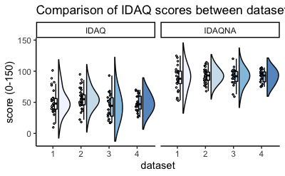

```r
source("R_rainclouds.R") #/Volumes/Project0255/code
#source("summarySE.R")
#idaq_sum <- summarySEwithin(DF.idaq, measurevar="score", betweenvars="dataset", withinvars= "scale", idvar="sub")
p <- DF.idaq %>%
  group_by(sub,dataset, scale) %>%
  ggplot(.,aes(x=dataset,y=score,fill=dataset, group = dataset))+
  geom_flat_violin(position=position_nudge(x = .2, y = 0),adjust =2, trim = FALSE, alpha = .75, colour = "Black") +
  geom_point(aes(colour = dataset), position=position_jitter(width = .05), size = .5, shape = 21, colour = "Black") +
  geom_boxplot(aes(x=dataset,y=score),position=position_nudge(x = .1, y = 0),outlier.shape = NA, alpha = .5, width = .1, colour = "black") +
  #geom_errorbar(data = idaq_sum, aes(x=dataset,y=score, ymin = score-ci, ymax = score+ci), position=position_nudge(x = .3, y = 0), width = .05)+
  scale_fill_brewer(palette = "Blues") +
  scale_colour_brewer(palette = "Blues") +
  theme_classic() +
  ylab(paste("score (0-150)")) +
  ggtitle(paste("Comparison of IDAQ scores between datasets")) +
  theme(legend.position="none") +
  facet_wrap(~scale)
p
```

## 5.7 Median and interquartile range per dataset

Calculate the median IQR per dataset (table S2):

```r
DF.idaq %>%
  #filter(!sub %in%  sub_ex) %>%
  group_by(sub,dataset, scale) %>%
  summarise(score = sum(score)) %>%
  group_by(dataset, scale) %>%
  summarise(median = median(score),
            iqr = IQR(score))
```

| dataset | scale | median | iqr |
| --- | --- | --- | --- |
| 1 | IDAQ | 48.0 | 17.00 |
| 1 | IDAQNA | 88.0 | 20.00 |
| 2 | IDAQ | 55.0 | 16.00 |
| 2 | IDAQNA | 93.0 | 13.00 |
| 3 | IDAQ | 44.5 | 29.50 |
| 3 | IDAQNA | 92.0 | 16.00 |
| 4 | IDAQ | 47.0 | 20.50 |
| 4 | IDAQNA | 93.0 | 15.75 |

# 6. fROI results

## 6.1 Data wrangling

Create function to load the data for the different networks:

```r
library(fs)
roi_extract <- function(datasetno, substart, subend, network, nroi) {

  dir_ls(paste("dataset_", datasetno, "/derivatives/roi/", network, sep = ""), regexp = "\\.tsv$") %>%
    map_dfr(read.delim, sep = "\t", .id = "id", header = FALSE)  %>%
    mutate(dataset = datasetno) %>%
    mutate(network = network) %>%
    mutate(network = str_extract(network, "tom|pain")) %>%
    mutate(id = str_extract(id, "dmpfc|mmpfc|vmpfc|ltpj|rtpj|prec|amcc|lmfg|rmfg|ls2|rs2|linsula|rinsula")) %>%
    rename(roi = id, contrast = V1) %>%
    mutate(sub = rep(substart:subend, times=nroi, each=1)) %>%
    select(5,3,4,1:2)
}
```

Load the data for the Theory-of-Mind network:

```r
DF.d1 <- roi_extract(1, 101, 129, "tom", 6)
DF.d2.a <- roi_extract(2, 201, 202, "tom/201_202", 6)
DF.d2.b <- roi_extract(2, 203, 235, "tom", 6)
DF.d3 <- roi_extract(3, 301, 322, "tom", 6)
DF.d4 <- roi_extract(4, 401, 422, "tom", 6)
DF.temp <- bind_rows(DF.d1, DF.d2.a, DF.d2.b, DF.d3, DF.d4)
```

Load the data for the Pain Matrix:

```r
DF.d1 <- roi_extract(1, 101, 129, "pain", 7)
DF.d2.a <- roi_extract(2, 201, 202, "pain/201_202/", 7)
DF.d2.b <- roi_extract(2, 203, 235, "pain", 7)
DF.d3 <- roi_extract(3, 301, 322, "pain", 7)
DF.d4 <- roi_extract(4, 401, 422, "pain", 7)
DF.roi <- bind_rows(DF.temp, DF.d1, DF.d2.a, DF.d2.b, DF.d3, DF.d4)
rm(DF.d1, DF.d2.a, DF.d2.b, DF.d3, DF.d4, DF.temp, DF.test)
```

Reorder ROI names for plots:

```r
order <- c("rtpj", "ltpj", "prec", "vmpfc","mmpfc","dmpfc", "rs2", "ls2", "rinsula", "linsula", "rmfg", "lmfg", "amcc")
DF.roi <- DF.roi %>%
  mutate_at(vars(-contrast),as.factor) %>%
  group_by(sub, dataset) %>%
  mutate(roi = fct_relevel(roi, order))
```

## 6.2 Theory-of-Mind network activation across datasets:

Plot the ToM activity across regions and datasets:

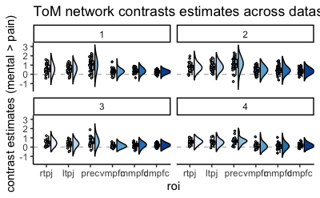

```r
p1 <- DF.roi %>%
  filter(network == "tom") %>%
  ggplot(.,aes(x=roi,y=contrast,fill=roi))+
  geom_hline(yintercept = 0, color = "grey", linetype = 2) +
  geom_flat_violin(position=position_nudge(x = .2, y = 0),adjust =2, trim = FALSE, colour = "Black") +
  geom_point(aes(colour = roi, fill = roi), position=position_jitter(width = .05), size = .5, shape = 21, colour = "Black") +
  geom_boxplot(aes(x=roi,y=contrast),position=position_nudge(x = .1, y = 0),outlier.shape = NA, alpha = .5, width = .1, colour = "black") +
  theme_classic() +
  ylab(paste("contrast estimates (mental > pain)")) +
  scale_fill_brewer(palette = "Blues") +
  scale_colour_brewer(palette = "Blues") +
  ggtitle(paste("ToM network contrasts estimates across datasets")) +
  theme(legend.position="none") +
  facet_wrap(~dataset)
p1
```

## 6.3 Differences in ToM activation between datasets:

Test if for potential differences between datasets and rois:

```r
tom.compare <- brm(
  formula = contrast ~ roi * dataset,
  data = DF.roi %>% filter(network == "tom"),
  #family  = cumulative("logit"),
  file = 'tom.compare.RDS'
)
summary(tom.compare)
```

```
 Family: gaussian
  Links: mu = identity; sigma = identity
Formula: contrast ~ roi * dataset
   Data: DF.roi %>% filter(network == "tom") (Number of observations: 648)
Samples: 4 chains, each with iter = 2000; warmup = 1000; thin = 1;
         total post-warmup samples = 4000

Population-Level Effects:
                  Estimate Est.Error l-95% CI u-95% CI Rhat Bulk_ESS Tail_ESS
Intercept             0.60      0.08     0.45     0.75 1.00     1342     2591
roiltpj              -0.03      0.11    -0.24     0.18 1.00     1872     2830
roiprec               0.39      0.10     0.18     0.60 1.00     1896     2151
roivmpfc             -0.29      0.11    -0.50    -0.08 1.00     2070     2687
roimmpfc             -0.23      0.11    -0.44    -0.02 1.00     1699     2870
roidmpfc             -0.34      0.11    -0.56    -0.13 1.00     1910     2816
dataset2              0.18      0.10    -0.02     0.38 1.00     1633     2490
dataset3             -0.15      0.11    -0.37     0.08 1.00     1859     2690
dataset4             -0.03      0.12    -0.27     0.20 1.00     1818     2126
roiltpj:dataset2      0.09      0.15    -0.20     0.37 1.00     2030     2977
roiprec:dataset2     -0.08      0.14    -0.35     0.20 1.00     2164     2860
roivmpfc:dataset2    -0.03      0.14    -0.31     0.25 1.00     2321     2870
roimmpfc:dataset2    -0.09      0.14    -0.37     0.19 1.00     1506     3054
roidmpfc:dataset2    -0.10      0.14    -0.37     0.19 1.00     2002     2898
roiltpj:dataset3     -0.10      0.16    -0.41     0.22 1.00     2235     2712
roiprec:dataset3     -0.21      0.16    -0.53     0.10 1.00     2261     2701
roivmpfc:dataset3    -0.02      0.16    -0.33     0.29 1.00     2203     3083
roimmpfc:dataset3    -0.00      0.16    -0.32     0.30 1.00     2321     3007
roidmpfc:dataset3     0.11      0.16    -0.21     0.42 1.00     2378     2685
roiltpj:dataset4     -0.04      0.16    -0.36     0.28 1.00     2183     2531
roiprec:dataset4     -0.29      0.16    -0.61     0.03 1.00     2445     2650
roivmpfc:dataset4    -0.15      0.16    -0.46     0.17 1.00     2339     2596
roimmpfc:dataset4    -0.22      0.16    -0.53     0.11 1.00     2245     2733
roidmpfc:dataset4    -0.06      0.16    -0.39     0.26 1.00     2253     2756

Family Specific Parameters:
      Estimate Est.Error l-95% CI u-95% CI Rhat Bulk_ESS Tail_ESS
sigma     0.40      0.01     0.38     0.42 1.00     4688     3061

Samples were drawn using sampling(NUTS). For each parameter, Bulk_ESS
and Tail_ESS are effective sample size measures, and Rhat is the potential
scale reduction factor on split chains (at convergence, Rhat = 1).
```

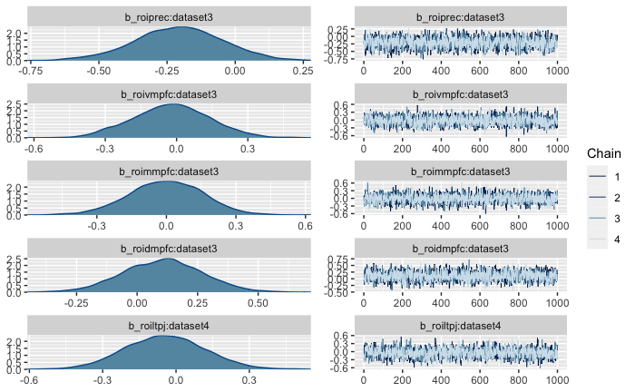

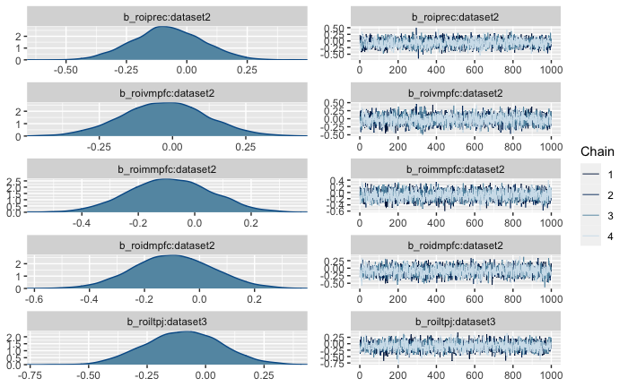

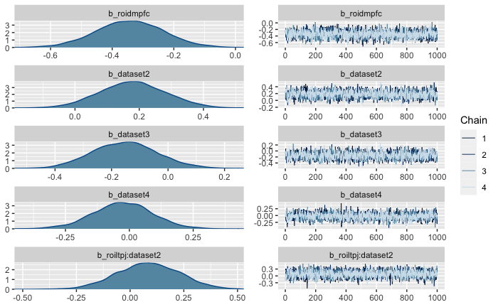

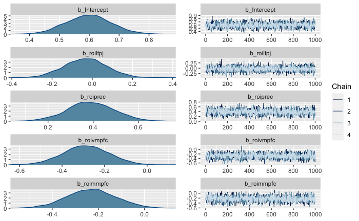

[figure not shown]

```r
plot(tom.compare)
```

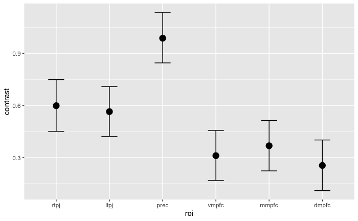

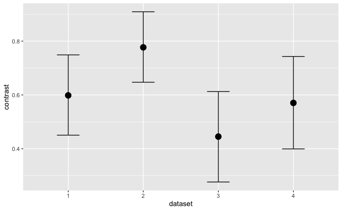

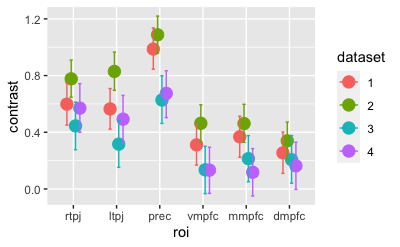

```r
conditional_effects(tom.compare)
```

## 6.4 Pain Matrix activation across datasets

Plot the Pain Matrix activity across regions and datasets:

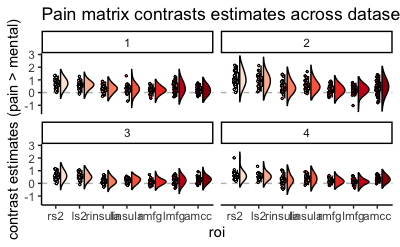

```r
p2 <- DF.roi %>%
  filter(network == "pain") %>%
  ggplot(.,aes(x=roi,y=contrast,fill=roi))+
  geom_hline(yintercept = 0, color = "grey", linetype = 2) +
  geom_flat_violin(position=position_nudge(x = .2, y = 0),adjust =2, trim = FALSE, colour = "Black") +
  geom_point(aes(colour = roi, fill = roi), position=position_jitter(width = .05), size = .5, shape = 21, colour = "Black") +
  geom_boxplot(aes(x=roi,y=contrast),position=position_nudge(x = .1, y = 0),outlier.shape = NA, alpha = .5, width = .1, colour = "black") +
  theme_classic() +
  ylab(paste("contrast estimates (pain > mental)")) +
  scale_fill_brewer(palette = "Reds") +
  scale_colour_brewer(palette = "Reds") +
  ggtitle(paste("Pain matrix contrasts estimates across datasets")) + theme(legend.position="none") +
  facet_wrap(~dataset)
p2
```

## 6.5 Differences in Pain Matrix activation between datasets:

Test if for potential differences between datasets and rois:

```r
pain.compare <- brm(
  formula = contrast ~ roi * dataset,
  data = DF.roi %>% filter(network == "pain"),
  #family  = cumulative("logit"),
  file = 'pain.compare.RDS'
)
summary(pain.compare)
```

```
 Family: gaussian
  Links: mu = identity; sigma = identity
Formula: contrast ~ roi * dataset
   Data: DF.roi %>% filter(network == "pain") (Number of observations: 756)
Samples: 4 chains, each with iter = 2000; warmup = 1000; thin = 1;
         total post-warmup samples = 4000

Population-Level Effects:
                    Estimate Est.Error l-95% CI u-95% CI Rhat Bulk_ESS Tail_ESS
Intercept               0.73      0.07     0.59     0.86 1.00     1162     1832
roils2                 -0.14      0.09    -0.32     0.05 1.00     1699     2755
roirinsula             -0.42      0.10    -0.61    -0.24 1.00     1592     2578
roilinsula             -0.44      0.10    -0.63    -0.26 1.00     1428     2394
roirmfg                -0.53      0.10    -0.72    -0.34 1.00     1480     2705
roilmfg                -0.35      0.10    -0.54    -0.17 1.00     1735     2682
roiamcc                -0.54      0.10    -0.72    -0.35 1.00     1508     2540
dataset2                0.38      0.09     0.19     0.56 1.00     1645     2137
dataset3               -0.11      0.11    -0.32     0.09 1.00     1224     2211
dataset4               -0.08      0.10    -0.29     0.12 1.00     1646     2118
roils2:dataset2        -0.04      0.13    -0.29     0.21 1.00     2224     3033
roirinsula:dataset2    -0.24      0.13    -0.49     0.01 1.00     2080     2455
roilinsula:dataset2    -0.12      0.13    -0.38     0.14 1.00     2196     3008
roirmfg:dataset2       -0.35      0.13    -0.61    -0.09 1.00     2097     2840
roilmfg:dataset2       -0.53      0.13    -0.79    -0.27 1.00     2249     2796
roiamcc:dataset2       -0.12      0.13    -0.37     0.13 1.00     2070     3017
roils2:dataset3         0.05      0.15    -0.24     0.34 1.00     1786     2526
roirinsula:dataset3    -0.01      0.15    -0.29     0.28 1.00     1711     2230
roilinsula:dataset3     0.06      0.15    -0.22     0.35 1.00     1485     2966
roirmfg:dataset3        0.05      0.15    -0.24     0.34 1.00     1734     2535
roilmfg:dataset3       -0.04      0.15    -0.33     0.25 1.00     1881     2503
roiamcc:dataset3        0.22      0.15    -0.07     0.51 1.00     1839     2592
roils2:dataset4         0.06      0.14    -0.22     0.33 1.00     2078     2870
roirinsula:dataset4     0.07      0.15    -0.21     0.35 1.00     2141     2734
roilinsula:dataset4     0.18      0.15    -0.10     0.47 1.00     2028     2931
roirmfg:dataset4        0.07      0.15    -0.22     0.36 1.00     2079     2366
roilmfg:dataset4       -0.17      0.15    -0.45     0.13 1.00     2059     2524
roiamcc:dataset4        0.24      0.15    -0.04     0.53 1.00     2147     2756

Family Specific Parameters:
      Estimate Est.Error l-95% CI u-95% CI Rhat Bulk_ESS Tail_ESS
sigma     0.36      0.01     0.35     0.38 1.00     5135     3017

Samples were drawn using sampling(NUTS). For each parameter, Bulk_ESS
and Tail_ESS are effective sample size measures, and Rhat is the potential
scale reduction factor on split chains (at convergence, Rhat = 1).
```

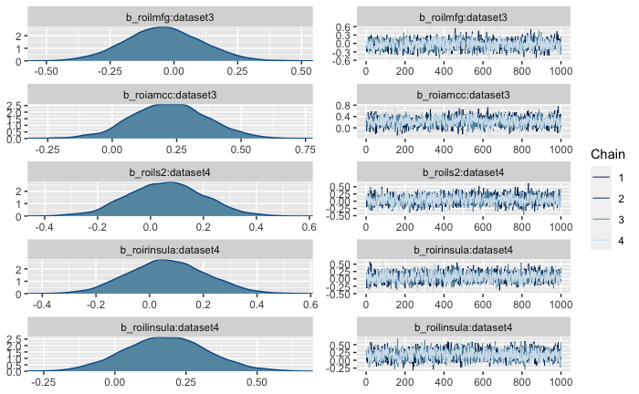

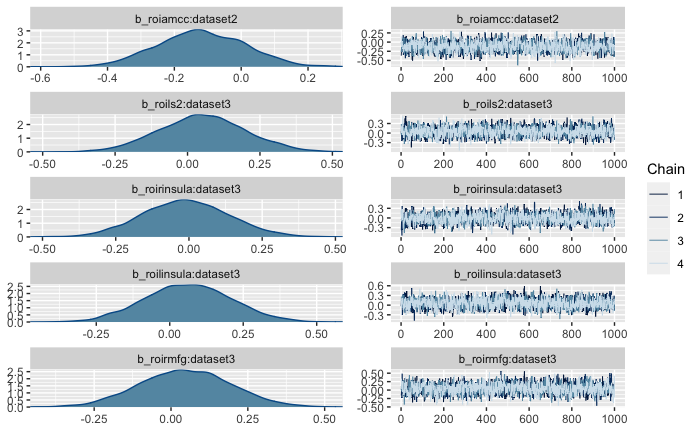

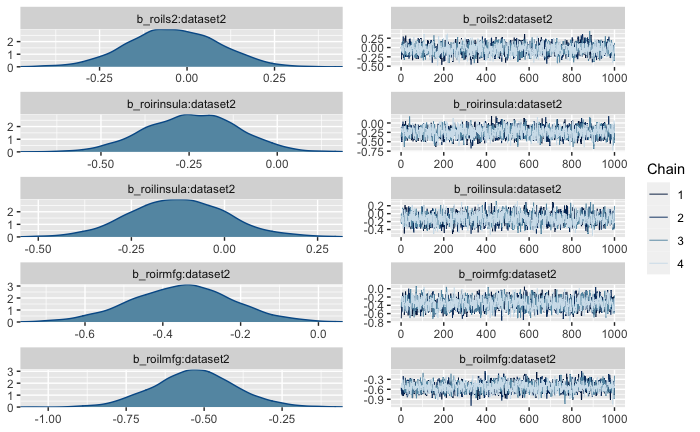

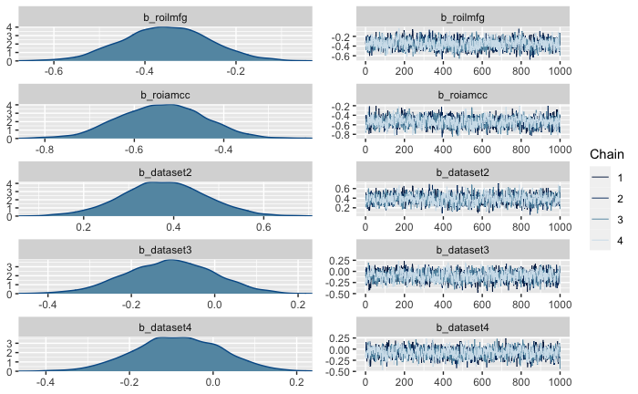

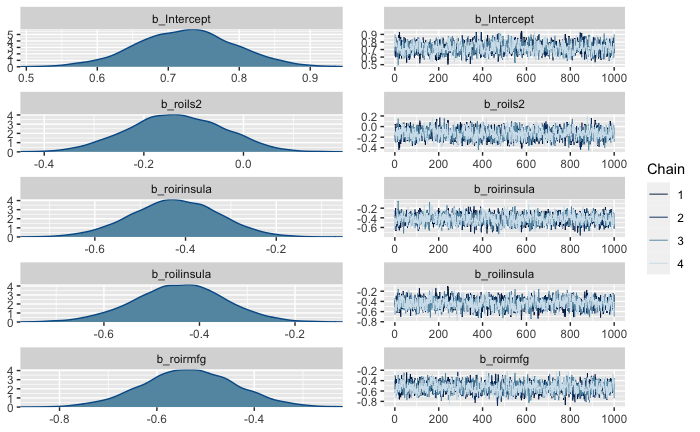

[figure not shown]

```r
plot(pain.compare)
```

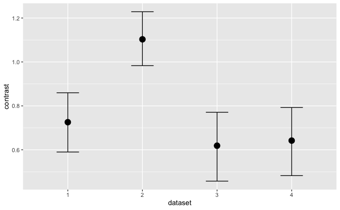

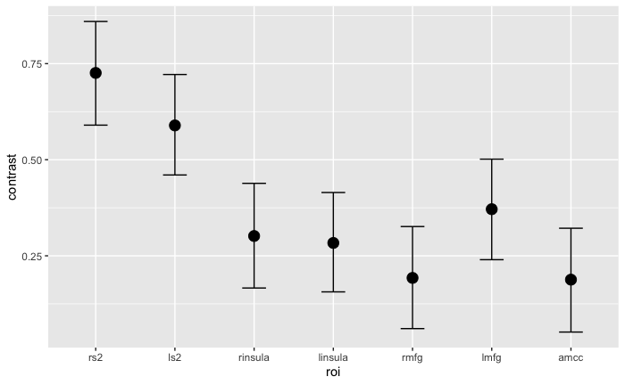

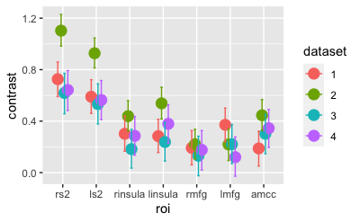

```r
conditional_effects(pain.compare)
```